# Herrings length report

Jakub Kwitowski

22 stycznia 2017

# 1 ANALIZA PROBLEMU

W związku z różnego rodzaju czynnikami zauważono stopniowy spadek rozmiaru śledzia oceanicznego wyławianego w Europie. Analizie został poddany zbiór danych opisujacy pomiary śledzi i warunki w jakich żyły z ostatnich 60 lat. Celem raportu jest próba odnalezienia zależności, które mają wpływ na rozmiar śledzia.

# 2 ANALIZA DANYCH

Opisy kolumn występujących w zbiorze

| Kolumna | Opis |
| --- | --- |
| length | długość złowionego śledzia [cm] |
| cfin1 | dostępność planktonu [zagęszczenie Calanus finmarchicus gat. 1]; |
| cfin2 | dostępność planktonu [zagęszczenie Calanus finmarchicus gat. 2]; |
| chel1 | dostępność planktonu [zagęszczenie Calanus helgolandicus gat. 1]; |
| chel2 | dostępność planktonu [zagęszczenie Calanus helgolandicus gat. 2]; |
| lcop1 | dostępność planktonu [zagęszczenie widłonogów gat. 1]; |
| lcop2 | dostępność planktonu [zagęszczenie widłonogów gat. 2]; |
| fbar | natężenie połowów w regionie [ułamek pozostawionego narybku]; |
| recr | roczny narybek [liczba śledzi]; |
| cumf | łączne roczne natężenie połowów w regionie [ułamek pozostawionego narybku]; |
| totaln | łączna liczba ryb złowionych w ramach połowu [liczba śledzi]; |
| sst | temperatura przy powierzchni wody [°C]; |
| sal | poziom zasolenia wody [Knudsen ppt]; |
| xmonth | miesiąc połowu [numer miesiąca]; |
| nao | oscylacja północnoatlantycka [mb]. |

# 3 BIBLIOTEKI

Analiza danych została wykonana w oparciu o poniższe biblioteki

```r
library(readr)
library(dplyr)
```

```r
library(knitr)
library(shiny)
library(ggplot2)
library(corrplot)
library(caret)
library(randomForest)
```

oraz została zapewniona powtarzalność wyników

```r
set.seed(1)
```

# 4 CZYSZCZENIE ZBIORU

Zbiór został wczytany a brakujące dane zostały zastąpione przez symbol “NA” w celu łatwiejszego późniejszego przetwarzania

```r
herrings <- read_csv("sledzie.csv", col_names = TRUE, na = c("?", "NA"))
```

Wszystkie pola NA zostały zastąpione średnią wartością z danej kolumny w której wystąpiła brakująca wartość

```r
herringsReplaceByMean <- herrings
columnMean <- colMeans(herringsReplaceByMean, na.rm=TRUE)
index <- which(is.na(herringsReplaceByMean), arr.ind=TRUE)
herringsReplaceByMean[index] <- columnMean[index[,2]]
```

# 5 PODSUMOWANIE ZBIORU

Zbiór danych historycznych jest pokaźny. Zawiera szczegółowe dane statystyczne z dla każdego śledzia.

1. Liczba wierszy w zbiorze

```r
knitr::kable(nrow(herringsReplaceByMean))
```

| 52582 |
| --- |

2. Liczba kolumn w zbiorze

```r
knitr::kable(ncol(herringsReplaceByMean))
```

[output not shown]

3. Padsumowanie statystyczne: Tabela zawiera wartości minimalne, maksymalne, mediany, średnie dla wszyskich zmienny w zbiorze

```r
knitr::kable(summary(herringsReplaceByMean))
```

|  | X1 | length | cfin1 | cfin2 | chel1 | chel2 | lcop1 | lcop2 | fbar | recr | cumf | totaln | sst | sal | xmonth | nao |
| --- | --- | --- | --- | --- | --- | --- | --- | --- | --- | --- | --- | --- | --- | --- | --- | --- |
|  | Min. : 0 | Min. :19.0 | Min. : 0.0000 | Min. : 0.0000 | Min. : 0.000 | Min. : 5.238 | Min. : 0.3074 | Min. : 7.849 | Min. :0.0680 | Min. : 140515 | Min. :0.06833 | Min. : 144137 | Min. :12.77 | Min. :35.40 | Min. : 1.000 | Min. :-4.89000 |
|  | 1st Qu.:13145 | 1st Qu.:24.0 | 1st Qu.: 0.0000 | 1st Qu.: 0.2778 | 1st Qu.: 2.469 | 1st Qu.:13.589 | 1st Qu.: 2.5479 | 1st Qu.:17.808 | 1st Qu.:0.2270 | 1st Qu.: 360061 | 1st Qu.:0.14809 | 1st Qu.: 306068 | 1st Qu.:13.63 | 1st Qu.:35.51 | 1st Qu.: 5.000 | 1st Qu.:-1.89000 |
|  | Median :26291 | Median :25.5 | Median : 0.1333 | Median : 0.7012 | Median : 6.083 | Median :21.435 | Median : 7.1229 | Median :25.338 | Median :0.3320 | Median : 421391 | Median :0.23191 | Median : 539558 | Median :13.86 | Median :35.51 | Median : 8.000 | Median : 0.20000 |
|  | Mean :26291 | Mean :25.3 | Mean : 0.4458 | Mean : 2.0248 | Mean :10.006 | Mean :21.221 | Mean : 12.8108 | Mean :28.419 | Mean :0.3304 | Mean : 520367 | Mean :0.22981 | Mean : 514973 | Mean :13.87 | Mean :35.51 | Mean : 7.258 | Mean :-0.09236 |
|  | 3rd Qu.:39436 | 3rd Qu.:26.5 | 3rd Qu.: 0.3603 | 3rd Qu.: 1.9973 | 3rd Qu.:11.500 | 3rd Qu.:27.193 | 3rd Qu.: 21.2315 | 3rd Qu.:37.232 | 3rd Qu.:0.4560 | 3rd Qu.: 724151 | 3rd Qu.:0.29803 | 3rd Qu.: 730351 | 3rd Qu.:14.16 | 3rd Qu.:35.52 | 3rd Qu.: 9.000 | 3rd Qu.: 1.63000 |
|  | Max. :52581 | Max. :32.5 | Max. :37.6667 | Max. :19.3958 | Max. :75.000 | Max. :57.706 | Max. :115.5833 | Max. :68.736 | Max. :0.8490 | Max. :1565890 | Max. :0.39801 | Max. :1015595 | Max. :14.73 | Max. :35.61 | Max. :12.000 | Max. : 5.08000 |

# 6 ANALIZA WARTOŚCI ZMIENNYCH

```r
for(i in names(herringsReplaceByMean)){
  ggplot(herringsReplaceByMean, aes(x=herringsReplaceByMean[i])) + geom_histogram(aes(fill = ..count..)) + scale_fill_gradient("Count", low = "#132b44", high = "#55b1f7") + labs(x=i, y="count")

  ggplot(herringsReplaceByMean, aes(x=herringsReplaceByMean[i])) + geom_density() + labs(x=i, y="density")

 }
```

[output not shown]

# 7 KORELACJA MIĘDZY ZMIENNYMI

Dzięki heatmapie czyli graficznemu przedstawienie korelacji między zmiennymi możemy zaobserować ciekawe zależności, które występują między zmiennymi w zbiorze.

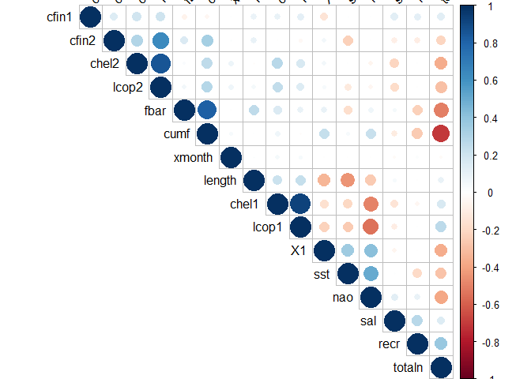

```r
corrplot(cor(herringsReplaceByMean), type = "upper", order = "hclust", tl.col = "black", tl.srt = 45)
```

Wykres pokazuje dość silne trywialne korelacje dodatnie.

Zmiana natężenia połowów powoduje zmianę łącznego rocznego natężenie połowów 1.natężenie połowów w regionie [ułamek pozostawionego narybku 2.łączne roczne natężenie połowów w regionie

Zmiana zagęszczenia planktonu chel1 powoduje zmianę zagęszczenia planktonu lcop1 1.chel1: dostępność planktonu [zagęszczenie Calanus helgolandicus gat. 1]; 2.lcop1: dostępność planktonu [zagęszczenie widłonogów gat. 1];

Zmiana zagęszczenia planktonu chel2 powoduje zmianę zagęszczenia planktonu lcop2  
1.chel2: dostępność planktonu [zagęszczenie Calanus helgolandicus gat. 2]; 2.chel2: dostępność planktonu [zagęszczenie widłonogów gat. 2];

Istnieje również korelacja ujemna. Wraze ze wzrostem łącznego rocznego natężenia połowów w regionie [ułamek pozostawionego narybku], spada łączna liczba ryb złowionych w ramach połowu [liczba śledzi]

# 8 WYKRES PREZENTUJĄCY ZMIANĘ ROZMIARU ŚLEDZIA W CZASIE

W związku z tym iż zbiór danych nie posiada dokładnego znacznika czasowego względem roku połowu w grę wchodzi założenie o chronologiczności zbioru. Zmienna czasowa jest przedstawiona jako przyrostowa liczba rekordów (obserwacji).

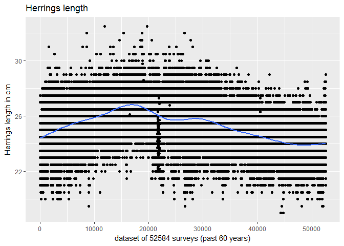

```r
ggplot(herringsReplaceByMean, aes(X1, length)) + geom_point() + geom_smooth(se=TRUE) + ggtitle("Herrings length") + labs(x="dataset of 52584 surveys (past 60 years)", y="Herrings length in cm")
```

# 9 REGRESJA

Zastosowanie regresji pozwoli przewidzieć wielkość wyłowianych śledzi w przyszłości. Ze zbioru eleminuję kolumnę porządową X1, która nie powinna być brana pod uwagę podczas analizy. Zbiór został podzielony na uczący i testowy.

```r
fit<-select(herringsReplaceByMean,-X1)
fit<-lm(length ~ ., fit)
summary(fit)
```

```
##
## Call:
## lm(formula = length ~ ., data = fit)
##
## Residuals:
##     Min      1Q  Median      3Q     Max
## -7.6451 -0.9372  0.0042  0.9290  6.9724
##
## Coefficients:
##               Estimate Std. Error t value Pr(>|t|)
## (Intercept)  5.709e+01  6.331e+00   9.018  < 2e-16 ***
## cfin1        1.399e-01  6.910e-03  20.248  < 2e-16 ***
## cfin2        2.245e-02  3.008e-03   7.465 8.48e-14 ***
## chel1       -2.490e-03  1.272e-03  -1.958   0.0502 .
## chel2       -2.802e-03  1.724e-03  -1.626   0.1040
## lcop1        1.410e-02  1.187e-03  11.880  < 2e-16 ***
## lcop2        9.098e-03  1.412e-03   6.442 1.19e-10 ***
## fbar         6.185e+00  8.298e-02  74.539  < 2e-16 ***
## recr        -3.547e-07  2.784e-08 -12.739  < 2e-16 ***
## cumf        -1.029e+01  1.571e-01 -65.491  < 2e-16 ***
## totaln      -5.571e-07  5.167e-08 -10.781  < 2e-16 ***
## sst         -1.249e+00  1.995e-02 -62.574  < 2e-16 ***
## sal         -3.997e-01  1.792e-01  -2.231   0.0257 *
## xmonth       8.605e-03  2.172e-03   3.962 7.45e-05 ***
## nao          2.482e-02  4.076e-03   6.090 1.14e-09 ***
## ---
## Signif. codes:  0 '***' 0.001 '**' 0.01 '*' 0.05 '.' 0.1 ' ' 1
##
## Residual standard error: 1.367 on 52567 degrees of freedom
## Multiple R-squared:  0.3165, Adjusted R-squared:  0.3163
## F-statistic:  1739 on 14 and 52567 DF,  p-value: < 2.2e-16
```

```r
summary(fit)$r.squared
```

```
## [1] 0.3164881
```

```r
rmse<-function(num) {
  sqrt(mean(num^2))
}

rmse(fit$residuals)
```

```
## [1] 1.366484
```

```r
n<-nrow(herringsReplaceByMean)
trainIndex<-sample(1:n, size = round(0.7*n), replace=FALSE)
training<-herringsReplaceByMean[trainIndex ,]
test<-herringsReplaceByMean[-trainIndex ,]

training_ctrl<-trainControl(
    method = "cv",
    number=5
)

fit<-train(length ~ .,
    data = training,
    trControl = training_ctrl,
    method = "rf",
    ntree = 2
)

predi <- predict(fit, newdata = test)
```

# 10 WAŻNOŚĆ ATRYBUTÓW

```r
randfor_fit<-select(herringsReplaceByMean,-X1)
randfor<-randomForest(length ~ .,randfor_fit)
print(randfor)
```

```
##
## Call:
##  randomForest(formula = length ~ ., data = randfor_fit)
##                Type of random forest: regression
##                      Number of trees: 500
## No. of variables tried at each split: 4
##
##           Mean of squared residuals: 1.314559
##                     % Var explained: 51.88
```

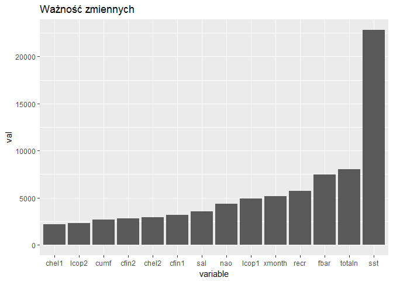

```r
randfor_importance<-importance(randfor)
randfor_importance<-data.frame(variable = rownames(randfor_importance), val = randfor_importance[, 1])
randfor_importance$variable<-factor(randfor_importance$variable, levels = randfor_importance[order(randfor_importance$val), "variable"])

ggplot(randfor_importance, aes(x = variable, y = val)) + geom_bar(stat = "identity") + ggtitle("Ważność zmiennych")
```

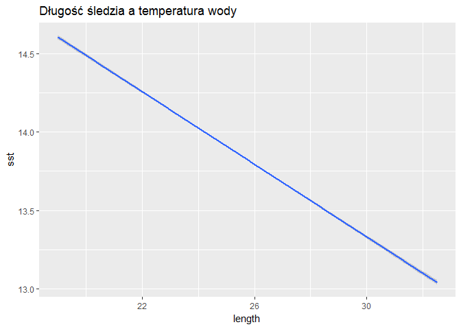

```r
ggplot(herringsReplaceByMean, aes(x = length, y = sst)) + geom_smooth(method = "lm") + ggtitle("Długość śledzia a temperatura wody")
```

# 11 WNIOSKI

W WYNIKU PRZEPROWADZONYCH OBLICZEŃ ISTANIEJE POWAŻNA PODSTAWA ABY TWIERDZIĆ, ŻE DŁUGOŚĆ ŚLEDZIA JEST ZWIĄZA Z TEMPERATURĄ PRZY POWIERZCHNI WODY. ROZMIAR ŚLEDZIA JEST DŁUŻSZY W PRZYPADKU GDY TEMPERATURA WODY JEST NIŻSZA